# Introduction to Git

Authors & reviewers: Michael Hoskin, Jonathon Mellor, Jeroen Minderman, Tom Albone, Tom White, Georgina Dangerfield

Course Updated: November 2022 | Need help? Contact the team.

# Learning Objectives

At the end of this course, you will be able to:

- Use Git to manage files using the command line interface (CLI)
- Use Git as a version control system and adopt its workflows
- Understand the differences between Git and remote repositories (e.g. Github and Gitlab)
- Use workflows that allow collaboration with others by linking local repositories with remotes

# 1 Introduction

Git is a version-control system used to track changes in source code during software development. It was created in 2005 to help with the development of Linux, and is an incredibly common way of managing your code.

It allows multiple developers to work with the same code simultaneously, while tracking the history of every line of code written. It also allows users to create branches, where code can be edited and experimented with, while leaving the original code untouched, removing the chance of overwriting essential code. The image below demonstrates a common practice when not using version control software such as Git:

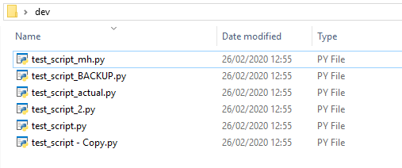

Git can also be used to backup your work onto remote servers to assist with collaboration and mitigate data loss in the event of a system failure. This brings us to an important distinction:

- Git is the version control system
- GitLab/Github are remote hosts which run the cloud based systems built on Git.

Please ensure before continuing the course you have completed **all** the pre-course requirements, including requesting GitLab (or your department’s equivalent) and requesting access to a project.

## 1.1 Git Bash

Git Bash is a program used to interact with Git via command line, though when it is installed, a Git GUI (Graphical User Interface) is included. Although typically used on Windows machines, Git Bash uses the Linux dialect of command line command. For example, to list the contents of a directory:

- Linux (and Git Bash) uses `ls`
- Windows uses `dir`

If Git is installed, a Git Bash window can be opened to a specific directory by opening the folder, right clicking, and selecting `Git Bash Here`.

Git Bash can be also opened in the Start menu, but you will need to navigate within Git Bash using command line commands to the location of each project.

If you do not have Git Bash, other command line interfaces can be used in a very similar fashion. For ONS devices, we will just look at Git Bash. Use the interface suggested in your department.

[figure not shown]

### 1.1.1 Syntax

Git Bash may seem intimidating at first if you are unfamiliar with command line tools. We use the command line to more directly work with our computer, increasing our ability to specify what we want and develop code at pace.

GitLab comes with a user interface which allows some small changes to be made, this should be done sparingly as it is not as clear to others what you have done, and does not scale well with large projects.

When we open the Git Bash window we will see a line with a `$`, this is where we type our commands. We can type one command line at a time here.

To run the command you can press `Enter`.

Each part of a command is separated by a space, with each argument having some different effect on the command.

When doing Git based things all our commands start with `git` in the form:

```bash
$ git <other commands>
```

*Note, the `<>` are not included in real commands and are just placeholders.*

An example command would therefore be:

```bash
$ git add example_file.txt
```

Some other useful general command line commands for within Git Bash are:

```bash
$ cd folder/subfolder   # Change Directory (cd) to a folder within the current directory
$ cd ..                 # Change Directory to a level one higher
$ ls                    # List all folders and files within the current directory
```

## 1.2 Global Config Settings

When starting out using Git, there are a few key things that need to be set. The first one, is to tell Git who we are. This allows it to record which developer wrote which pieces of code, and allow you to work collaboratively.

```bash
$ git config --global user.name "Michael Hoskin"
$ git config --global user.email michael.hoskin@ons.gov.uk
```

If these aren’t set, it will have a guess at your details with an unknown amount of success - on a networked, government machine it will probably be able to get your email address, and a relevent username.

## 1.3 Creating a Repository

Once your config settings have been set, a new repository can be created on your computer. There are different ways of doing this, from creating a new, empty repository, to cloning one that can be found on the internet.

The simplest way, is to initialise a new local repository using the following command:

```bash
$ git init
```

```bash
Initialized empty Git repository in //NDATA11/hoskim1$/Desktop/intro_to_git/.git/
```

This creates a hidden folder within your directory called `.git`, which stores the history of the repository. If that folder gets deleted, history is erased!

When working with real projects you will want to create a repository on your machine where you keep all your projects. We will refer to where your `.git` file is as the repository. After completing this course, create a new “Git Area” folder somewhere appropriate on your machine. If you work at ONS, this could be on your D: drive. If you work elsewhere, make sure to store your folder somewhere you have edit rights. This will be the parent folder of all your repositories. Each repository will have it’s own folder within, and it’s own `.git` file.

You can make an empty git repository within a specific directory by writing:

```bash
$ git init <directory>
```

## 1.4 Exercises

### Questions

1. Create a folder on your desktop called ‘Intro_to_Git’ and open Git Bash within it.
2. Update your Git Global Config Settings.
   - Set your `user.name` value to your name. Make sure the name is wrapped in quotes if there is a space in it!
   - Set your `user.email` value to your email address. As the email address has no spaces in it, is does not need to be wrapped in quotes.
3. Initialise a new Git repository (repo) within the ‘Intro_to_Git’ directory.

### Answers

**Question 1**

1. Create a folder on your desktop called ‘Intro_to_Git’ and open Git Bash within it.

Right click on your desktop and select `New` / `Folder`, and name it `Intro_to_Git`. Open up the folder, right click and select `Git Bash Here`.

**Question 2**

2. Update your Git Global Config Settings.

```bash
$ git config --global user.name "Your name"
$ git config --global user.email an.appropriate.email@domain.com
```

**Question 3**

3. Initialise a new Git repository (repo) within the directory.

```bash
$ git init
```

# 2 Basic Git

Git will “track” files that you tell it to track.

It will keep a history of the changes made to those files, but only for the files it has been told to track.

New files created need to be added to the repo or Git will not know the files exist. Just because a file is in the folder with `.git` does not mean git is aware it exists.

This is a multiple step process:

1. Once changes have been made to a file such as new lines of code written, or an entirely new file added to the directory, the changes need to be `added`. This tells Git to track the file, and keep an eye on any further changes that are made.
2. Once a set of files have been added, they need to be `committed`. This takes the changes that have been `added`, and `commits` them to the official history of the repository.

`Commits` include a message written by the user, which provides a summary of the changes that have been made within the `commit`, so the history of the repository can be easily seen, just by looking at the `commit` log.

We can think of this process like we are sending a parcel:

1. Items must initially be `added` to the parcel
2. Further items can be `added` or existing ones removed or changed until the parcel is ready to be sent
3. The parcel can be wrapped using a `commit` once it is ready to be sent

We can re-wrap the parcel or add more elements to it until it is in the postal system. After this it cannot be changed. How we send it to the postal system (using a `push`) will be covered later.

## 2.1 Status

One of the most useful git commands is `status`.

This shows the status of the repository, whether any changes have been made, whether there are any new files which haven’t yet been `added`, or whether any have been deleted or renamed. It’ll also tell you which branch you are on (more on this to come).

```bash
$ git status
```

```bash
On branch master
Changes not staged for commit:
  (use "git add <file>..." to update what will be committed)
  (use "git checkout -- <file>..." to discard changes in working directory)

      modified:  preprocessing.py

Untracked files:
  (use "git add <file>..." to include what will be committed)

      initialise_pipeline.py

no changes added to commit (use "git add" and/or "git commit -a")
```

This message includes a lot of useful information:

- The first line states the branch the repository is currently on.
- The next section (`Changes not staged for commit:` onwards) includes any known changes to any of the files within the repository - anything which has been previously tracked - and has had changes applied to it.
- Below (`Untracked files:` onwards) includes the names of any file which has not been tracked.

Git is also very good at giving you ideas of commands you can use - to `add` files, undo changes, or commit them.

> You may seem the branch names `master` and `main` being used interchangeably. Both refer to the “default” branch, i.e. typically the branch that holds the copy of the work that is considered the definitive (i.e. “non-working”) version. Any new features or changes are typically developed in other branches, and merged into `main` or `master` when they have been reviewed and are considered complete (more on merging later).  
> GitHub and other git ecosystem software are moving away from the default branch being called `master`, and [replacing it with `main`](https://github.com/github/renaming).  
> For continuity, in the current version of this course we have retained the use of `master` for the time being, but it should be stressed this could be read as `main`.

## 2.2 Add

To `add` file modifications, or new files, the command `git add` is used. This needs to be followed by a parameter specifying what file or files need to be `added.`

```bash
$ git add .                       # Add all created, modified, deleted or renamed files
$ git add -u                      # Add all modified files - will not add any new files
$ git add 'preprocessing.py'      # Add a specific file, 'preprocessing.py'
$ git add directoryname           # Add a directory and its contents
```

Once a change or changes have been `added`, `git status` will show a different result:

```bash
$ git status
```

```bash
On branch master
Changes to be committed:
  (use "git reset HEAD <file>..." to unstage)

      modified:  preprocessing.py
...
```

The different parameters that can be used with `git add` allows for flexibility in what you add to your code base. When starting out we often just use the `.` add all parameter for ease.

## 2.3 Commit

Once a set of files have been added, they can be `committed`.

This stores the changes as a permanent item in the history of the repo, with an associated message. It will only `commit` files that have been `added`, any untracked changes will not be included.

The `-m` modifier used below indicates that the following string (in quotes) should be stored as the message for that `commit`. The message should be succinct and to the point, and state the changes in an impersonal manner made within that `commit`.

```bash
$ git commit -m "Updated preprocessing code to handle column name variance"
```

```bash
[master 398a264] Updated preprocessing code to handle column name variance
 1 file changed, 2 insertions(+), 1 deletion(-)
```

Adding a commit message is a crucial part in documenting your code. It allows others and your future self to understand what happened at a certain point in the development.

There are a range of different style guides for commit messages, but the main point is that they should be informative and describe what has been done since the last commit.

Without an informative message it will be difficult to trace back to when a bug was added to the code making it difficult to return to before it was introduced.

We should include usful information about the commit such as a description of the type of commit:

- fix - a bug fix
- feat - a new feature
- doc - documentation changes
- and more.

An example of a style guide for version control is given in the [Data Science Campus’ GitHub](https://datasciencecampus.github.io/coding-standards/version-control.html).

Adding the `-m` modifier to the command allows you to add a short message, however we will also want to add longer clear documentation to commits.

By not including the `-m "commit message"` part of the command this causes Git Bash to enter something called Vim. Vim is a text editor which allows the editing of code with the Git Bash terminal. For beginners it is best to avoid Vim until you are comfortable with the principles of Git.

```bash
$ git commit
```

Produces:

```bash
# Please enter the commit message for your changes. Lines starting
# with '#' will be ignored, and an empty message aborts the commit.
# On branch dev
# Your branch is up-to-date with 'origin/dev'.
#
# Changes to be committed:
#   modified:   intro_to_git.Rmd
#   new file:   prep/Feedback.docx
#   new file:   prep/~$edback.docx
#
~
~
~
"Some command things here"
```

> **NOTE:** You can enter the command section of Vim by pressing `Esc`. In order to exit Vim type `:q`, to save then exit Vim type `:wq`, to exit without saving type `:!q` the command is then followed by the `Enter` key.

After committing, the console will tell you how many files have been changed, and the total number of line insertions and deletions.

The seven characters after the word `master` are a reference to the ID of the `commit` message. This can be used to step back through previous `commits`, in case a previous change needs to be undone.

We can also add multiple descriptions to a commit. This allows us to add a brief description, and one in more detail.

```bash
$ git commit -m "consice description" -m "longer description with more detail of what has been changed"
```

We would use the Vim editor for even longer multi-line commit messages to best document our code. For now we will just use the `-m` method.

## 2.4 Log

To view previous `commits`, the repository `log` can be accessed.

```bash
$ git log --oneline
```

```bash
398a264 Updated preprocessing code to handle column name variance
2faebe6 initial commit of preprocessing
6bb41ce test commit
```

`--oneline` is added to make the log more succinct - each `commit` gets added onto one line. Without the modifer, each `commit` will be spread over about five lines, but carry far more detail about when it was made, and who it was made by.

## 2.5 Exercises

### Questions

1. Check the status of your newly created repository.
2. Create a text file within the directory called `test_file.txt` and add the following line to it:
   - `This is the first line of the file`
   - Don’t forget to save the file!
3. Check the status again.
4. Add the file to the repository.
5. Check the status again!
6. Commit the file with a relevent message
   - Often, the initial commit of a new repository will be something like ‘Initial commit’!
   - Make sure the commit message is wrapped in quotation marks - either single or double, as long as it’s consistent!
7. Check the status again.
8. Check the repository log. Try both looking at the full version, and the version shortened to oneline.

### Answers

**Question 1**

1. Check the status of your newly created repository.

```bash
$ git status
```

```bash
On branch master

Initial commit

nothing to commit (create/copy files and use "git add" to track)
```

**Question 2**

2. Create a text file within the directory called `test_file.txt` and add the following line to it:
   - `This is the first line of the file`
   - Don’t forget to save the file!

Right click within the directory and press `New` / `Text Document`. Add the line mentioned in the question to the text document, and then save it.

**Question 3**

3. Check the status again.

```bash
$ git status
```

```bash
On branch master

Initial commit

Untracked files:
  (use "git add <file>..." to include in what will be committed)

test_file.txt

nothing added to commit but untracked files present (use "git add" to track)
```

**Question 4**

4. Add the file to the repository.

```bash
$ git add .
```

Or

```bash
$ git add test_file.txt
```

**Question 5**

5. Check the status again!

```bash
$ git status
```

```bash
On branch master

Initial commit

Changes to be committed:
  (use "git rm --cached <file>..." to unstage)

new file:   test_file.txt
```

We can see that our newly created file has been added. It hasn’t yet been committed.

**Question 6**

6. Commit the file with a relevent message
   - Often, the initial commit of a new repository will be something like ‘Initial commit’!
   - Make sure the commit is wrapped in quotation marks - either single or double, as long as it’s consistent!

```bash
$ git commit -m "Initial commit of test_file"
```

```bash
[master (root-commit) 86d7ea6] initial commit of test_file
1 file changed, 1 insertion(+)
create mode 100644 test_file.txt
```

**Question 7**

7. Check the status again.

```bash
$ git status
```

```bash
On branch master
nothing to commit, working tree clean
```

**Question 8**

8. Check the repository log. Try both looking at the full version, and the version shortened to oneline.

```bash
$ git log
```

```bash
commit 86d7ea6cdb88bae51ef68a794a17b622b8b8784e
Author: michael hoskin <michael.hoskin@ons.gov.uk>
  Date:   Wed Feb 26 16:13:43 2020 +0000

initial commit of test_file
```

```bash
$ git log --oneline
```

```bash
86d7ea6 initial commit of test_file
```

# 3 Branches

One of the key advantages of Git, is the ability to create specific branches to complete different tasks in the code. All the work above has been completed in the `master` branch, the default first branch. Branches should be created for specific tasks, and then get “merged” back into the master branch when complete.

Often, a “development” branch is created as an intermediate level branch - feature branches get merged into development, development gets merged into master.

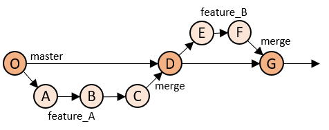

## 3.1 Checking Current Branches

To look at the current branches in a repo, `git branch` can be used. This lists all of the local branches, or with an added modifier, all the branches on any associated remote repository as well.

Remote repositories will be covered in the Collaboration section, but are fundamentally a cloud stored copy of the repository allowing collaboration with colleagues.

```bash
$ git branch                # List all local branches
$ git branch -a             # List all local and remote branches
```

## 3.2 Checkout

Branches can be moved between by using the command `git checkout <branchname>`. This will move the repository to the branch specified. When moving between branches, files might seem to appear or disappear in our File Explorer if they are in just one of the branches and not in the other.

For example, you create a file `new_feature_A.txt` on branch `feature_A_branch` then commit it. If you then move to `feature_B_branch` then `new_feature_A.txt` will not appear in your folder.

`git checkout branchname` will move the repository to the specified branchname. If there is no local branch called `branchname`, Git will look at remote tracking branches, and if one exists, checkout a tracked version of that branch.

Other parameters can be added to the checkout command:

- `-b` will create the new branch specified, and then move into it.
- `--track origin/branchname` will checkout a tracked version of the remote branch `branchname` - equivalent to `git checkout branchname` if no local branch `branchname` can be found.

The remote branch/`origin` refers to branches held on a remote server such as your team’s GitLab.

```bash
$ git checkout feature_A            # Move to the `feature_A` branch. The branch must exist.
$ git checkout -b feature_B         # Create the `feature_B` branch and move into it.
$ git checkout --track origin/feature_C  # Create a local branch tracking `origin/feature_C`.
```

Instead of checking out specific branches, specific commits can be checked out, by replacing the branch name with the commit ID - the short form of which can be found from a `git log --oneline` command.

```bash
$ git checkout 602a1ee          # Checkout the commit with commit ID specified.
```

The first checkout we will be doing will always be *from* the `master` branch, as this is the only branch that first exists. However, we can create a new branch from any existing branch.

Which branch we want to create a new one from depends on the feature we want to create, and which phase of development we are in.

If we want to make changes to a certain feature, we would checkout a new branch from the branch where that feature is being developed.

If we wanted to create an entirely new feature we could branch off from the `develop` branch.

The naming convention and branch workflow you use will be determined by any team style guide you have.

If this does not exist there are some general style guides you can follow such as [this one](https://github.com/chrisjlee/git-style-guide).

We would recommend you discuss with an appropriate person in your department/team as to what branch workflow to follow. An example is given at the end of this course.

## 3.3 Merge

Once work has been completed within a feature branch, it needs to be merged back in. `git merge mergingbranch targetbranch` will take the commits from `mergingbranch`, and attempt to automatically merge them into `targetbranch`.

Before you merge a branch, **you must move to the target branch** by using `git checkout targetbranch`.

- Source Branch - the branch with the new changes
- Target Branch - the branch you want add the new changes to

```bash
# If you are on the feature_B branch you need
# to change to the target branch
$ git checkout development
```

```bash
$ git merge feature_B development       # Merge branch feature_B into development
```

If the changes made within the `mergingbranch` do not conflict with any other commits within the `targetbranch`, the merge will be successful.

### 3.3.1 Merge Conflicts

Merge conflicts arise when two merging commits have made edits to the same parts of the same files. Git is often clever enough to be able to merge changes made to different parts of the same file, but can fall down at times.

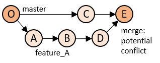

When a merge fails to auto merge the branch name will convert to the target branch name, followed by a pipe `|`, and the word MERGING to indicate that the merge is half complete.

We also get the following message in our Git Bash.

It falls to the user to fix the merge conflict, before committing the completed merge.

```bash
$ git merge feature_B development
```

```bash
Auto-merging preprocessing.py
CONFLICT (add/add): Merge conflict in preprocessing.py
Automatic merge failed; fix conflicts and then commit the result.

hoskim1@ONS22675 MINGW64 //NDATA11/hoskim1$/Desktop/working_git (development|MERGING)
$
```

The status will also specify that there are conflicts to fix, and list the files with changes that have been `both added` - by both of the merging branches.

To resolve these issues, open the conflicting files, locate the conflicts, and choose which version of the code should be retained. Conveniently, the file will have added some extra identifying lines around the conflicting areas.

Before each conflicting section, the line `<<<<<<< HEAD` will be added, followed by the content from the target branch - the one being merged into. A line of equals signs - `=======` will signify the end of that branch’s code, and lead into the version from the merging branch. That will end with the line `>>>>>>> feature_B`, with the name of the merging branch.

```
<<<<<<< HEAD
dev code
can be found
in here
...
=======
feature code
can be found
in here
...
>>>>>>> feature_B
```

To resolve each conflict, edit the conflicting code to retain only the lines that you want, then delete the three identifying lines. Repeat for each conflict - CTRL-F can be useful to find them, it is unlikely your code will naturally have the line `<<<<<<< HEAD` in it.

Once you have made these changes, add then commit them. The branch you are on in Git Bash will go from displaying `(development|MERGING)` to just `(development)`. Your branches have now been merged.

## 3.4 Delete

Branches should be deleted when they are no longer useful - normally after they have been merged successfully and since abandoned.

A different modifier can be added to `git branch` to remove old branches - `-d` or `-D`.

Care should be taken when removing branches - if they have not been merged successfully, their contents could be lost!

```bash
$ git branch -d feature_B       # Delete branch feature_B Will only work if the branch has been merged!
$ git branch -D feature_B       # Delete branch feature_B Will work regardless of whether the branch has been merged.
```

The modifier is case sensitive. If it is lowercase, it will only work if the branch has been merged. If uppercase, it will delete the branch without checking, and could result in lost work.

As a result - we would advise you use `-d` by default, and only then use `-D` if you are confident that’s what you want to do.

After completing the exercises below, you can take a deeper dive into git branching by completing the tasks at https://learngitbranching.js.org/.

## 3.5 Exercises

### Questions

1. Create and checkout a new branch called `dev`
2. Create a new file within the `Intro_to_Git` folder called `dev_test.txt`. Add a line of text to it, then `add` it within Git, and `commit` it with a useful `commit` message.
3. Merge the `dev` branch into the `master` branch.
4. Create and checkout a new branch called `alt_dev` from the `master`.
5. Create a new file `key_information.txt` and write your favourite colour. `add` and `commit` this change with an accompanying message.
6. Change to the `master` branch. Create the new file `key_information.txt` and write in your favourite animal. `add` and `commit` this change with an accompanying message.
7. Merge the `alt_dev` branch into the `master` branch. Resolve the conflicts such that the file contains both your favourite colour and animal. `add` and `commit` the resolved conflict file and check the status of the `master` branch.

### Answers

**Question 1**

1. Create and checkout a new branch called `dev`

```bash
$ git checkout -b dev
```

```bash
Switched to a new branch 'dev'
```

**Question 2**

2. Create a new file within the `Intro_to_Git` folder called `dev_test.txt`. Add a line of text to it, then `add` it within Git, and `commit` it with a useful `commit` message.

To create a new file, right click within the folder in Windows Explorer, then select New`/`Text Document`. Give it a name, open it, and add a line of text.

Then, within Git Bash:

```bash
$ git add .
$ git commit -m 'Added dev test file to repo'
```

```bash
[dev bd9330e] Added dev_test file to repo
1 file changed, 1 insertion(+)
create mode 100644 dev_test.txt
```

Note: A new file can be created from within Git Bash, by typing: `touch filename.txt`

**Question 3**

3. Merge the `dev` branch into the `master` branch.

Move to the `master` branch, then make the merge.

```bash
$ git checkout master
$ git merge dev master
```

```bash
Switched to branch 'master'
Updating 86d7ea6..bd9330e
Fast-forward
 dev_test.txt | 1 +
 1 file changed, 1 insertion(+)
 create mode 100644 dev_test.txt
```

**Question 4**

4. Create and checkout a new branch called `alt_dev` from the `master` branch.

```bash
$ git checkout -b alt_dev
```

```bash
Switched to a new branch 'alt_dev'
```

**Question 5**

5. Create a new file `key_information.txt` and write your favourite colour. `add` and `commit` this change with an accompanying message.

Create and open the `key_infomation.txt` file and change the contents of the first line.

Then, within Git Bash:

```bash
$ git add .
$ git commit -m "added favourite colour to key_information.txt"
```

```bash
[alt_dev 532f49e] added favourite colour to key_information.txt
 1 file changed, 1 insertion(+)
 create mode 100644 key_information.txt
```

**Question 6**

6. Change to the `master` branch. Create the new file `key_information.txt` and write in your favourite animal. `add` and `commit` this change with an accompanying message.

```bash
$ git checkout master
```

Create and open the `key_infomation.txt` file and change the contents of the first line.

Then, within Git Bash:

```bash
$ git add .
$ git commit -m "added favourite animal to key_information.txt"
```

```bash
[master 899373a] added favourite animal to key_information
 1 file changed, 1 insertion(+)
 create mode 100644 key_information.txt
```

**Question 7**

7. Merge the `alt_dev` branch into the `master` branch. Resolve the conflicts such that the file contains both your favourite colour and animal. `add` and `commit` the resolved conflict file and check the status of the `master` branch.

```bash
$ git merge alt_dev master
```

```bash
Auto-merging key_information.txt
CONFLICT (add/add): Merge conflict in key_information.txt
Automatic merge failed; fix conflicts and then commit the result.

melloj@ONS27519 MINGW64 //MDATA1/melloj$/Desktop/Intro_to_Git (master|MERGING)
$
```

Open the `key_information.txt` file.

The contents of `key_information.txt` then becomes:

```
<<<<<<< HEAD
Dog
=======
Blue
>>>>>>> alt_dev
```

Remove the conflict the file is changed to:

```
Dog
Blue
```

```bash
$ git add .
$ git commit -m "resolved conflicts"
```

```bash
[master bd0fe3d] resolved conflict
```

```bash
$ git status
```

```bash
On branch master
nothing to commit, working tree clean
```

# 4 Collaboration

Whilst being able to properly implement version control on your own machine is useful, the true power of Git is the ability to work collaboratively with colleagues on the same project.

By using Git and a remote repo hosting system changes made by an individual on their computer can be shared with others through a centralised point: the remote repository.

Having this remote repository integrated with the version control system allows a team to confidently work on the same project without fear of overwriting each others work. Changes made by others can be tracked and permission be given for merges or other potentially sensitive operations.

Working collaboratively allows us to peer review code when merging branches. This will increase the reliability of our code, and ensure that the quality is high. If you’re not sure how to review others code [this](https://devguide.ropensci.org/reviewtemplate.html) is a checklist worth exploring.

There are a range of different providers available for remote repo hosting services, the most common of which is Github. The ONS uses a system called GitLab, an open source alternative, which allows the department to host repos within the secure ONS ecosystem.

For ONS users how to set up, or work within a GitLab system will be the most relevant remote repo service. For this reason the course describes in detail how to use GitLab, however, should your department use another system the set up processes are very similar.

In general, it is good practice to make code produced available on online repositories so they can be viewed by anyone interested. However, as civil servants we must consider the nature of what information, data and documents we are putting into the public domain, just as we would with any other document.

## 4.1 Linking Remote to Local

You should already have a GitLab (or GitHub) account before starting this course. This means you are able to log into GitLab within a web browser and either view your own project space or your teams. This is where your projects are stored, however, you are currently unable to interact with this system via your own machine’s command line. This is because your computer and the remote repository service must be securely connected.

In order to make the connection to the remote server secure, you must generate a unique code, in this case an SSH key. This is an authentication method to ensure a secure connection.

Within the ONS, the following instructions will allow Git locally to connect with a remote GitLab repo. For other systems see the documentation on the individual system’s website, such as for [Github](https://help.github.com/en/github/getting-started-with-github/set-up-git).

This is done by writing the three lines of code below:

```bash
$ ssh-keygen -t rsa -b 4096 -C "<your work email>"

$ eval "$(ssh-agent -s)"

$ ssh-add id_rsa
```

For the first line, you will need to hit the enter key 3 times to use the default values for passwords. If an issue arises complaining about the lack of a .ssh folder, create it manually within your H drive.

You should then:

- Copy the .ssh folder from your H drive to C:\Users\your_username - replacing your_username with your windows username
- Open Command Prompt from your start bar and run:

```bash
> setx HOME C:\Users\your_username
```

- Open the file `H:/.ssh/id_rsa.pub` by right clicking and editing with either notepad / notepad++
- This file contains the key, which begins with `ssh ...`. Copy it to your clip board.
- Login to your GitLab and go to Settings in the top right, followed by selecting the ssh option, and then adding a key - name it something relevant such as the asset number of your device.

Your device should now be linked to the remote repo service.

## 4.2 Creating a Project

Your device is now able to connect to the remote system, which means you can now set up a project to work with using GitLab/GitHub.

To create a project in the remote system first enter the area of your remote repository host in which you would like the project to be based - typically your team’s area / group.

Within this space click “New Project”. This will prompt you to choose from either:

- Blank project
- Create from template
- Import project

The first of these is the primary one you will be using, but the other two are useful if; a template already exists for what you are trying to create, or if your project already exists on another remote repository service.

**Note:** On GitLab you must create a project within a group, and have the relevant permissions to do so.

[figure not shown]

Shows the page to create a new project on Gitlab.

The above image shows the creation of a new project in GitLab, while the below shows it in GitHub.

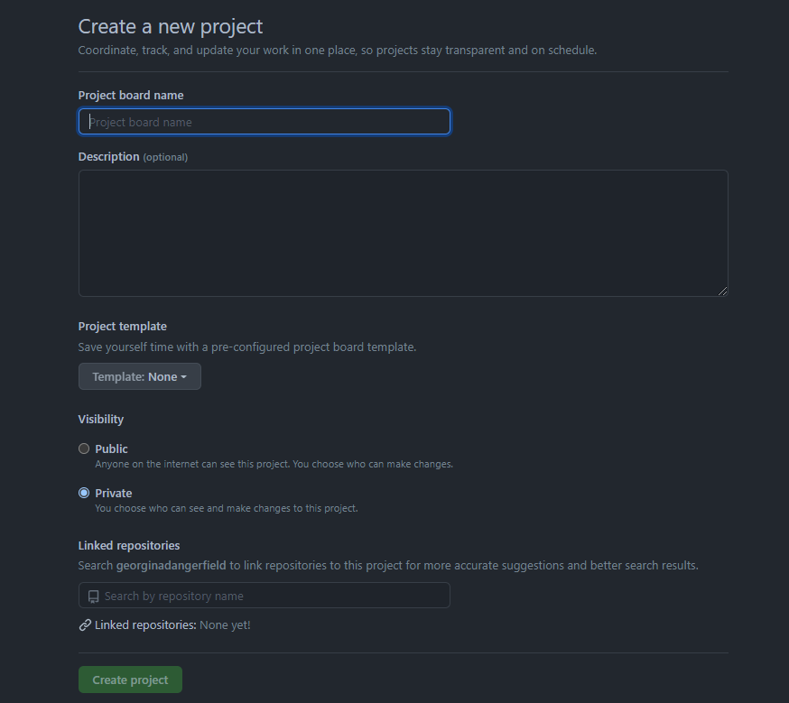

Shows the page to create a new project on Github

You are able to:

- Give the project a title.
- Designate where within the GitLab/Github directory the project will be located.
- Provide a description of the project.

In addition, there is a tick-box prompt for the generation of a `README` file. If you are starting the project from scratch, it is suggested to do this.

A `README` file contains useful information about the project, such as how to use it and what the project is for. You can also include things such as a contributors guide and licences here. This is done in a markdown language typically.

By creating the project you now have a location on the remote repo where your files can be stored, and as we have linked our machine to the repo we will be able to interact with it.

**Note:** The remote repository service will not automatically sync our project to our machine, we need to get the project onto our machine first, and then explicitally sync it. This is detailed in the sections below.

## 4.3 Clone

The project now exists in our remote repository, and we want to get it onto our machine. To do this we utilise a git command `clone`. We clone our remote repo to our computer.

To clone the project navigate to the location of the project in the remote repo and select the “Clone” button. This will produce two long text strings, one a SSH and the other a HTTP.

Copy the SSH string to your clipboard then open up Git Bash.

Navigate to the Git directory in Git Bash where you first wrote `git init` and the `.git` file is located.

You can paste in Git Bash using Ctrl + Shift + Insert.

To clone the project type:

```bash
$ git clone <the SSH string from your clipboard>
```

```bash
Cloning into 'name-of-project'...
```

Cloning is also used when starting work on a project that already exists on a remote repo. For example, if your team has been working on a task for a while and you have been asked to join them. You do not currently have the files on your computer, but do have access to the project on GitLab. You would therefore `clone` the project to access it on your computer.

You would now have an instance of the project associated with the remote repo on your device.

The name of the folder created will be that of the name of the project created.

If I have a project called “my-super-awesome-statistics-project-that-takes-ages-to-type” on the remote server this will create a folder on my machine of the same name. If this name is undesirable for any reason (poorly named, too long a name etc.) we can give the project a different folder name when we clone it by following the below syntax:

```bash
$ git clone <the SSH string from your clipboard> <folder name>
```

## 4.4 Fetch and Pull

As mentioned previously, our remote repo will not continuously sync files with our local repository (think: why could that that be a bad idea?).

This means the user needs to manually ensure that changes on the remote repository are tracked by our device. We must explicitly ask git to check what changes have been made since we last updated our local repo.

This is achieved by calling the `git fetch` command. By `fetch`ing we ask the remote repo to **inform** our device of all the updates to the branches that we are tracking.

We can add in the additional argument after `fetch` that specifies which remote repo we are referring to. By default the remote repos are assumed to be called `origin`. Which makes our full command:

```bash
$ git fetch origin
```

Producing a output of something like:

```bash
remote: Enumerating objects: 51, done.
remote: Counting objects: 100% (51/51), done.
remote: Compressing objects: 100% (47/47), done.
remote: Total 51 (delta 34), reused 8 (delta 4), pack-reused 0
Unpacking objects: 100% (51/51), done.
From np2rvlapxx507:Example_Group/Example_Subgroup/Example_Subject
   190a3dc..1161576  feature_A -> origin/feature_A
 * [new branch]      feature_B   -> origin/feature_B
```

Which fetches the information about our `origin` remote repo and shows us the changes at the remote.

We can see that the `fetch` command is getting tracking information about a `feature_A` branch and that a new branch called `feature_B` was created.

**Note:** *This does not change our files on our branches, it updates the information we have about the remote tracked branches.*

To actually get the changes made on the remote repo to our device we use a different command, `pull`.

When we use the `pull` command we are merging our current branch with a certain branch on the remote repo. If the merge is successful our local branch will therefore be up-to-date with the remote repo branch.

You should ensure that all changes to your local repository branch have been committed (called a clean working copy) before you try to `pull` from the remote repo to avoid untracked changes.

As `git pull` merges the remote repo to your local repo merge conflicts can occur. These can be handled in the same way as discussed in the ‘Merges’ section.

Performing a `pull` will automatically perform a `fetch` command first. We use `fetch` on its own to understand what has changed on the remote repo.

The full form of the `pull` command is:

```bash
$ git pull <remote name> <branch name>
```

If someone else has updated the `dev` branch of our repository we can pull it onto ours using:

```bash
$ git pull origin dev
```

Which will then list all of the changes made to yor local file, including insertions, deletions and files created/removed.

We can check the state of our local repos in relation to the remote repository using the command we have already introduced `status`.

```bash
$ git status
```

### 4.4.1 Tracking

We make the distinction between **tracked** and **untracked** branches. Tracked branches are those which are connected explicitly to a remote repository branch.

An untracked branch is one which is just local to the device being used. We can only pull/fetch and do other remote interacting operations with branches that are tracked.

## 4.5 Push

Up until now we have connected our machine to the remote repository, used `clone` to get the project onto our computer.

After some time there were changes to the project on the remote repo, as our colleague had been working on a branch. This caused the remote repo to be different from our local repo.

We then used `fetch` and `pull` to get then merge the changes between the remote repo and our local files. Great, we are up-to-date.

But now we want to work on the project ourselves, this means we need to make changes to our local repo, and then update the remote repo so it has our changes integrated.

This is done by using the `push` command. The `push` command allows you to merge a local branch to a remote branch. It follows the syntax below.

```bash
$ git push <remote name> <branch name>
```

If we were pushing to the `dev` branch, within the remote repo called the default `origin` we would write:

```bash
$ git push origin dev
```

Here is the outcome of pushing the changes to this section when this course was written.

```bash
Counting objects: 3, done.
Delta compression using up to 4 threads.
Compressing objects: 100% (3/3), done.
Writing objects: 100% (3/3), 847 bytes | 0 bytes/s, done.
Total 3 (delta 2), reused 0 (delta 0)
remote:
remote: =======================================================================
remote:
remote:      Should you require any help or support, please raise a call on
remote:      ServiceNow using the appropriate form. Your GitLab admins: are
remote:                       Berian Jones and Dave Smith
remote:
remote: =======================================================================
remote:
remote: To create a merge request for dev, visit:
remote:   http://np2rvlapxx507/Example_Group/Example_Project/merge_requests/new?merge_request%5Bsource_branch%5D=dev
remote:
To np2rvlapxx507:Example_Group/Example_Project.git
   d158358..1961239  dev -> dev
```

This is quite a lengthy return message. If you go through it line by line some of the terms may be familiar. The main point is that it has worked and updated the remote branch to what was committed in my local repository.

Here is a diagram of the different repos and commands to move files between them.

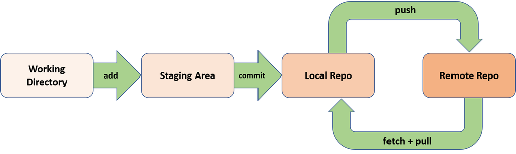

### 4.5.1 When to Push?

We want to make sure that all our changes to the code are being tracked and recorded at any time, that is why we want to commit early and often. However, we do not want to be constantly pushing up to the remote repo if our work is unfinished. Below are general rules of thumb for when to `commit` and `push`:

- `commit` when a “unit” of work is done; such as a new function made or part of a script written.
- `push` when a complete feature is made. This feature shouldn’t contain any bugs and should work well with the rest of the code.

Remember, we are documenting the code with each commit message, which allows us to trace when things are added. This allows us to work backwards if we made a mistake.

We then push when we are happy with the feature we have created and want others to be able to access the changes made to a specific branch.

## 4.6 Existing Projects

If you are wanting to create a Git repo for a project you have already started working on you can do so easily.

1. Ensure that you have a Git area on your local machine. This is achieved using `git init`, you should have one area to store all your projects.
2. Create a repo on the remote service you are using.
3. Clone that repo into your git area such that a folder connected to the remote exists.
4. Move the files from the project you are working on into the new cloned folder.
5. `add`, `commit` and `push` the files up to the remote repo.

This means you can now move any of your current projects onto GitLab without having to start from scratch!

## 4.7 Merging

We can now update remote repo branches with our local changes by using `push`. This allows us to alter the contents of a branch, but not to combine features from our different branches. For this we want to `merge` branches in the remote repo.

This is very similar to the merging we did previously, which was done locally on a computer. However, this time it is done using the remote repo, which means we can combine different branches worked on by different people.

Now you can be working on feature A, your collegue on feature B and you can then merge your work so a branch has both feature A *and* B.

This is achieved by creating a “Merge Request” on GitLab. Within the project area there is a tab on the left named “Merge Requests”, clicking on this will prompt a screen with the button “New merge request”. By selecting this the following screen will appear, allowing you to choose which branches you want to merge together.

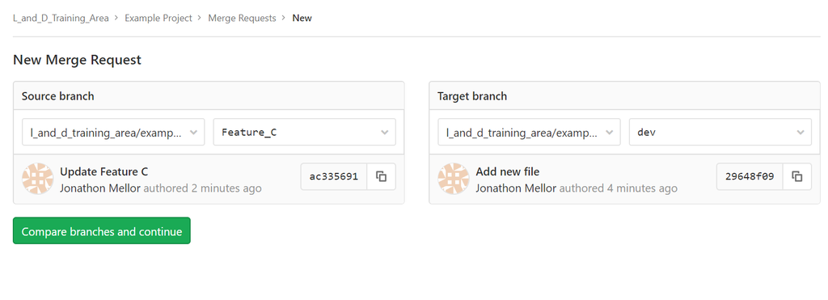

The source branch is the branch that is merged into the target branch. For example, if you have been working on some new *Feature C* and you want to merge it into the main development branch *dev* then you would do the merge shown above.

When creating a merge request there is a range of information you can give to it which will allow clearer documentation and customization. You can select the title of the request and add a description of the merge, and why it is necessary.

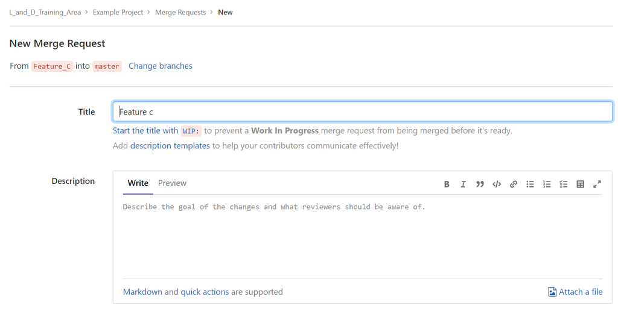

**Note:** Gitlab’s “merge request” feature is equivalent to GitHub’s “pull request” feature. Both are means of pulling changes from another branch or fork into your branch and merging the changes with your existing code Below, you can see the corresponding Github page when opening a pull request.

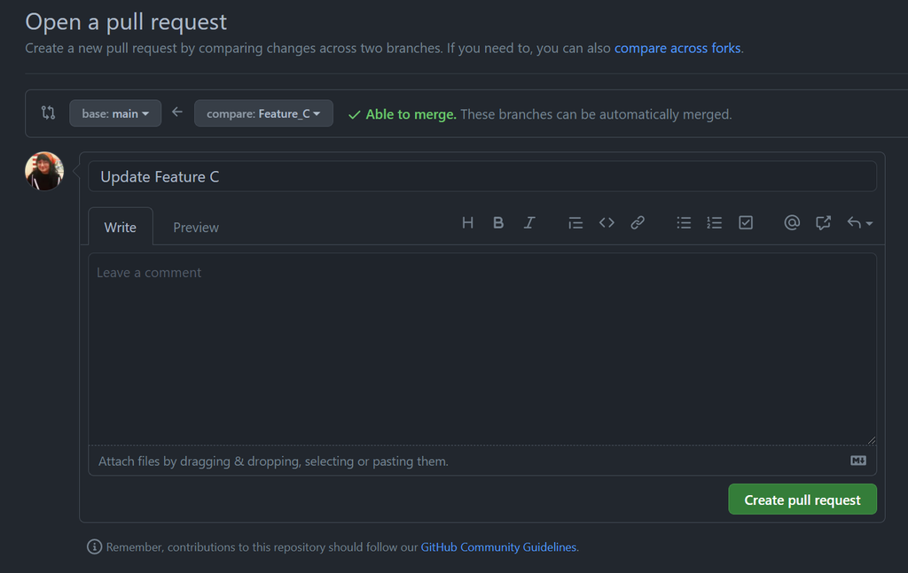

In addition, you can determine whether the source branch will be removed after the merge occurs. This can be useful if a feature is fully complete, but may not be the best idea if you will still need to work on elements of that source branch.

Other features of the merge request, such as who the reviewing of the request is assigned to can be detailed here.

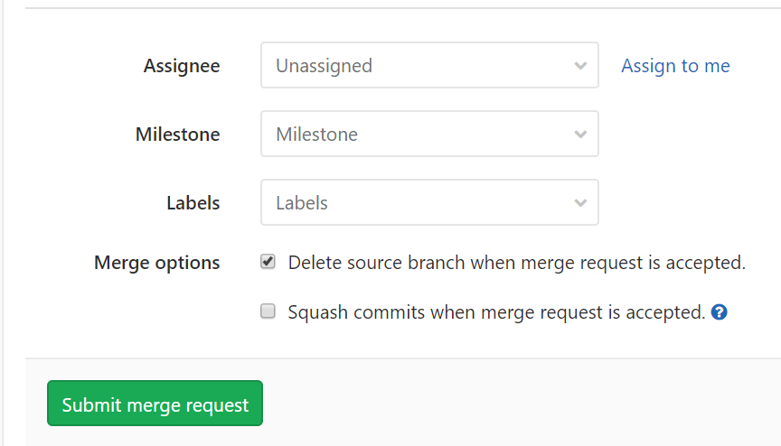

The merge request does not actually do the merge, it just documents the intention of the merge and tracks the relevant commits made to the source branch. Once the merge request is created, we now have a new screen that gives us information about it. This section will allow us to actually merge the two branches together by clicking “Merge”.

When working with others, or even just ourselves, we want to use the merge request as an opportunity to review the work done and double check **what** we are actually merging. GitLab provides a nice interface that lets us see the changes made, we as developers can determine how we want to handle any conflicts or whether we want to actually do the merge.

Peer reviewing code is an important part of working collaboratively, a merge request is a great time to put this into practice.

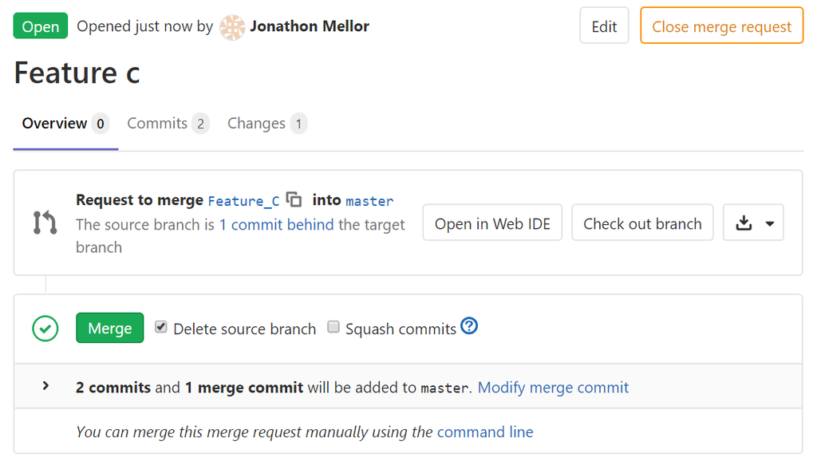

Merge conflicts can be resolved in GitLab itself in this case, the site will show us for each file and each conflict the difference between the source and target branches. You can then select which version of that section of code you would like to use and then commit this version.

### 4.7.1 Alternative Method

Merges with branches do not need to be done via the GitLab webpage. Instead they can be performed in command line using the methods we have already discussed.

First you would `add` then `commit` to the branch you are working on.

Then you would `fetch`/`pull` the target branch you would like to merge to.

You would then `merge` locally between your source and target branch, resolving any conflicts.

And finally you would `push` up to the remote target branch.

## 4.8 Example

Below is a diagram of what happens with two people working on the same project. Time goes from left to right. Bob and Alice are both working on different parts of the project, but there could be conflicts.

Alice not only has to submit a merge request, it also needs to be granted before the source and target branches merge.

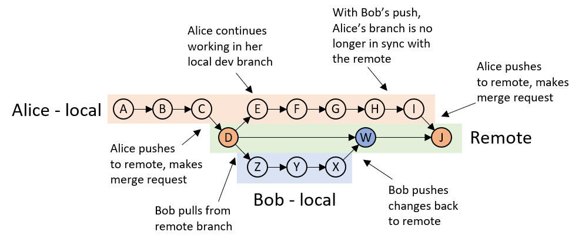

## 4.9 Exercise

### ONS

#### Answers

1. Write the following code below.

```bash
$ ssh-keygen -t rsa -b 4096 -C "<your work email>"

$ eval "$(ssh-agent -s)"

$ ssh-add id_rsa
```

Open the file `H:/.ssh/id_rsa.pub` using right click “Open With” > notepad / notepad++

`ssh ...`. Copy the ssh key.

Login to GitLab and go to Settings > ssh > add key and add it with a relevant name.

2. Read the `Group Information` page if you have not already.
4. Write the following code in your Git Repo directory location using Git Bash.

```bash
$ git clone <ssh value copied and pasted> <optional name of repo>
```

Remember you can paste into Git Bash using `Ctrl+Shift+Insert`.

5. Write the code:

```bash
$ git checkout -b <your username>
```

6. Either:

Got to the file location in your file explorer, and create a new file with notepad, entering in the relevant text.

Or:

In Git Bash move to the location you want the file and type:

```bash
$ cat > <filename>.txt
"Your input text here"
```

Then press `Crtl+d` at the end of the line.

7. Use the following commands:

```bash
$ git add .

$ git commit -m "relevant commit message"

$ git push origin <branch name>
```

8. Go onto the website, to the project, and click merge, entering the source branch (your username) and the target branch (`master`).
9. Resolve any conflicts using the GitLab IDE, or locally.
10. Write the following command in Git Bash:

```bash
$ git checkout master
```

11. Write the following command in Git Bash:

```bash
$ git status
```

12. Write the following command in Git Bash:

```bash
$ git fetch

$ git pull origin master
```

Open the file either by clicking it in File Explorer.

Or in Git Bash type:

```bash
cat <filename>
```

### Non-ONS

#### Questions

This will require you to have a GitHub account, or to use your department’s guidance on remote git repositories.

> **REMEMBER:** Do not use the GitHub account for your actual work.
1. Create your own project within GitHub called “practice”.
2. `clone` your newly created project onto your local device. You will need to be in your Git repo locally to do this in Git Bash.
3. Create and checkout a new branch `dev` locally.
4. Create a new text file called `development_feature.txt` in the repo. Add in some text of your choice to the file and *save* it.
5. `add` and `commit` this change with a relevant message. `push` this commit up to the remote repo.
6. Going onto GitHub, create a *merge request* between the source branch `dev` and target branch `master`. Using the GitHub website `merge` the two branches.
7. Solve any merge conflicts.
8. Using Git Bash, change to the `master` branch.
9. Check the `status` of the repo.
10. `fetch` and `pull` any changes to the `master` branch to your machine, open up your `feature_<your username>.txt` to see if your text is there.

#### Answers

1. On your GitHub account select either `New` > `Repository` or `Create New Repo`.
2. Copy the HTTPS or SSH URL at the top of the project.

Open Git Bash in your local Git Area.

Write the following code:

```bash
$ git clone <paste URL here>
```

Remember you can paste into Git Bash using `Ctrl+Shift+Insert`.

3. Write in Git Bash:

```bash
$ git checkout -b dev
```

4. Either:

Got to the file location in your file explorer, and create a new file with notepad, entering in the relevant text.

Or:

In Git Bash move to the location you want the file and type:

```bash
$ cat > development_feature.txt
"Your input text here"
```

Then press `Crtl+d` at the end of the line.

5. Use the following commands:

```bash
$ git add .

$ git commit -m "relevant commit message"

$ git push origin dev
```

6. Go onto the GitHub website, to the project, and click merge, entering the source branch (your username) and the target branch (`master`).
7. Resolve any conflicts using the GitHub IDE, or locally.
8. Write the following command in Git Bash:

```bash
$ git checkout master
```

9. Write the following command in Git Bash:

```bash
$ git status
```

10. Write the following command in Git Bash:

```bash
$ git fetch

$ git pull origin master
```

Open the file either by clicking it in File Explorer.

Or in Git Bash type:

```bash
cat development_feature.txt
```

# 5 Core Workflows

In this section we will work through examples of common things you will want to do using Git when working with your team.

## 5.1 Create a remote repo and open a local copy

We have been asked to start a new piece called the “New Statistic” which will require us to work on some code with others in the future. We first need to set up our remote repo to store the team’s work, and make a local copy so that we can work on it.

We first enter our team’s group area in GitLab as shown below.

[figure not shown]

And select “New Project”.

This allows us to fill in the details we want for our project. As this could be sensitive we are choosing the project to be private. We are going to also initialise the project with a README file so we do not need to create one later.

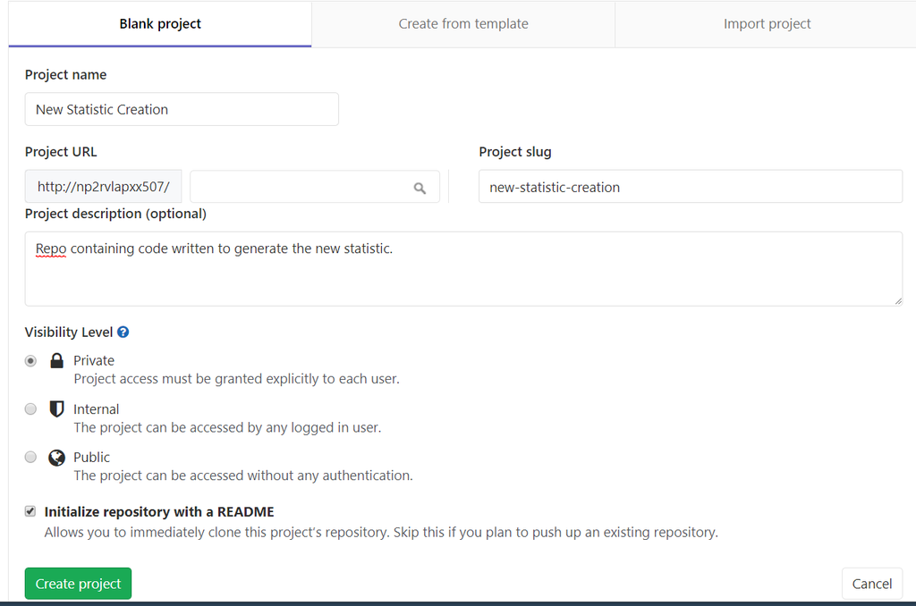

Now that the project exists on GitLab we can now `clone` it to our local Git area.

To do this we need the SSH value to `clone` with, which is obtained by selecting “clone” and copying the SSH value to the clipboard.

We then open Git Bash in our local Git directory (where our `.git` file is located).

In order to clone the project we type:

```bash
$ git clone <ssh value>
```

Remember, you can paste in Git Bash using `Ctrl+Shift+Insert`

In the case of our example the output looks like this:

```bash
Cloning into 'new-statistic-creation'...
remote: Enumerating objects: 3, done.
remote: Counting objects: 100% (3/3), done.
remote: Compressing objects: 100% (2/2), done.
remote: Total 3 (delta 0), reused 0 (delta 0), pack-reused 0
Receiving objects: 100% (3/3), done.
```

We can now move into that cloned directory in command line using

```bash
$ cd <project name>
```

or open it up in File Explorer.

## 5.2 Update a local repo from a remote

We are still working on our “New Statistic” project, however, we have been on annual leave for the past week. We know that the rest of the team has been working on the project so we don’t want to miss any of the changes made. The team has made a new branch `dev` while we were away, so we need to ge that branch as it is the most up-to-date.

In order to update out local branches with the changes made to the remote we are going to need to `fetch` and `pull` the remote repo to our device.

We first write:

```bash
$ git fetch
```

Which produces the output:

```bash
remote: Enumerating objects: 4, done.
remote: Counting objects: 100% (4/4), done.
remote: Compressing objects: 100% (2/2), done.
remote: Total 3 (delta 0), reused 0 (delta 0), pack-reused 0
Unpacking objects: 100% (3/3), done.
From np2rvlapxx507:l_and_d_training_area/new-statistic-creation
 * [new branch]      dev        -> origin/dev
```

This has told our local machine what changes have been made to the project, we can see that there is a new branch: `dev`.

In order to get this new branch and the changes to it we write:

```bash
$ git pull origin dev
```

Which produces an output:

```bash
From np2rvlapxx507:l_and_d_training_area/new-statistic-creation
 * branch            dev        -> FETCH_HEAD
Updating 2dbaab6..7da9fb9
Fast-forward
 new_code | 1 +
 1 files changed, 1 insertions(+)
 create mode 100644 new_code
```

This gives us the most up to date version of the `dev` branch that our team members have committed.

If we wanted to receive any changes made to the master branch then we would do:

```bash
$ git pull origin master
```

## 5.3 Add files to an existing remote repo

Our team has done a great job at working on the “New Statistic” project, and we now need to work on it. We have created a new file “crucial_pipeline.txt” that needs to be part of the `feature_pipeline` branch. This means we need to `push` our changes up to the remote repo.

We need to make sure we are on the correct branch before we start. This can be done by typing:

```bash
$ git status
```

We will `add` then `commit` our changes to our local repo by writing:

```bash
$ git add .
```

```bash
$ git commit -m "crucial_pipeline.txt designed and implemented"
```

```bash
$ git push origin feature_pipeline
```

Which produces the output on an ONS machine:

```bash
Counting objects: 3, done.
Delta compression using up to 4 threads.
Compressing objects: 100% (2/2), done.
Writing objects: 100% (3/3), 369 bytes | 0 bytes/s, done.
Total 3 (delta 0), reused 0 (delta 0)
remote:
remote: =======================================================================
remote:
remote:      Should you require any help or support, please raise a call on
remote:      ServiceNow using the appropriate form. Your GitLab admins: are
remote:                       Berian Jones and Dave Smith
remote:
remote: =======================================================================
remote:
remote: To create a merge request for dev, visit:
remote:   http://np2rvlapxx507/l_and_d_training_area/new-statistic-creation/merge_requests/new?merge_request%5Bsource_branch%5D=feature_pipeline
remote:
To np2rvlapxx507:l_and_d_training_area/new-statistic-creation.git
   7da9fb9..befebb1  feature_pipeline -> feature_pipeline
```

Our changes to the project can now be seen by our team. They will be able to `pull` it down to their local repo’s if they want to add to it.

# 6 Summary

In this course we have covered how to use Git for version controlling your code and how to work collaboratively in a team on the same project. Additionally we have shown *why* we would want to use a system such as Git.

We have looked at different elements required for using Git, these included:

- Setting up a Git repository on your local machine.
- Checking the status of our repository.
- Tracking files with `add` and committing changes with `commit`.
- Using branches and merging them.
- Creating and working with remote repositories.

We strongly suggest you practise a workflow both on your own and with your team before implementing what you have learned on this course in a real project.

If you are looking to expand your understanding of Git principles and the skills involved then we recommend the following external resources:

- [Git for humans](https://speakerdeck.com/alicebartlett/git-for-humans)
- [Github Skills](https://skills.github.com/)

# 7 Tips

- Commit early and often
- Git is a supplement to communicating with your team, it will not replace all workflows (let others know what you are doing!)
- All changes can be undone, but are harder to do the later you merge / commit.
- Use clear naming conventions for your branch names.
- Use clear commit descriptions to help you and others understand changes made to the code.
- We can “squash commits” - which makes our commit history clearer using [these commands](http://gitready.com/advanced/2009/02/10/squashing-commits-with-rebase.html).
- Encourage others to commit their code frequently or you will not be able to access it.

With some practice you will now be able to either set up or join your team using Git version control methods.

**Our team is trying to maintain a high response rate to our post-course survey to ensure we keep delivering quality training. Please go to the course on the learning hub and complete the “Post-Course Survey”.**

# 8 Command Glossary

In this section is useful commands that can be quickly referenced once you are using Git after the course. For a more comprehensive reference, [gitexplorer](https://gitexplorer.com/) is an excellent resource.

| Command | Purpose |
| --- | --- |
| `git init` | initialises a git repo in your current directory |
| `git add <file name>` | adds a specific file to be tracked by git and any changes made |
| `git add .` | adds all untracked files and changes made |
| `git status` | informs you whether changes have been made to the repo (new, untracked, deleted or renamed files) |
| `git commit` | commits all changes / new files added |
| `git commit -m "your message here"` | commits all changes / new files with a user defined message |
| `git checkout <branch name>` | moves to the specified repo |
| `git checkout -b <branch name>` | creates an new branch with a specified name and moves to it |
| `git merge <source branch> <target branch>` | attempts to merge the source branch with the target branch, you must be on the target branch to do this |
| `git branch -d <branch name>` | deletes the branch if it has been merged |
| `git branch -D <branch name>` | deletes branch regardless of if it has been merged |
| `git fetch` | retrieve all tracking information about the remote repo |
| `git pull <remote name> <branch name>` | merges the remote branch down to the local branch |
| `git push <remote name> <branch name>` | merges the local branch up to the remote branch |